# Food at College

## qqPlot

Let’s take a look at the normality of the data using a qqplot.

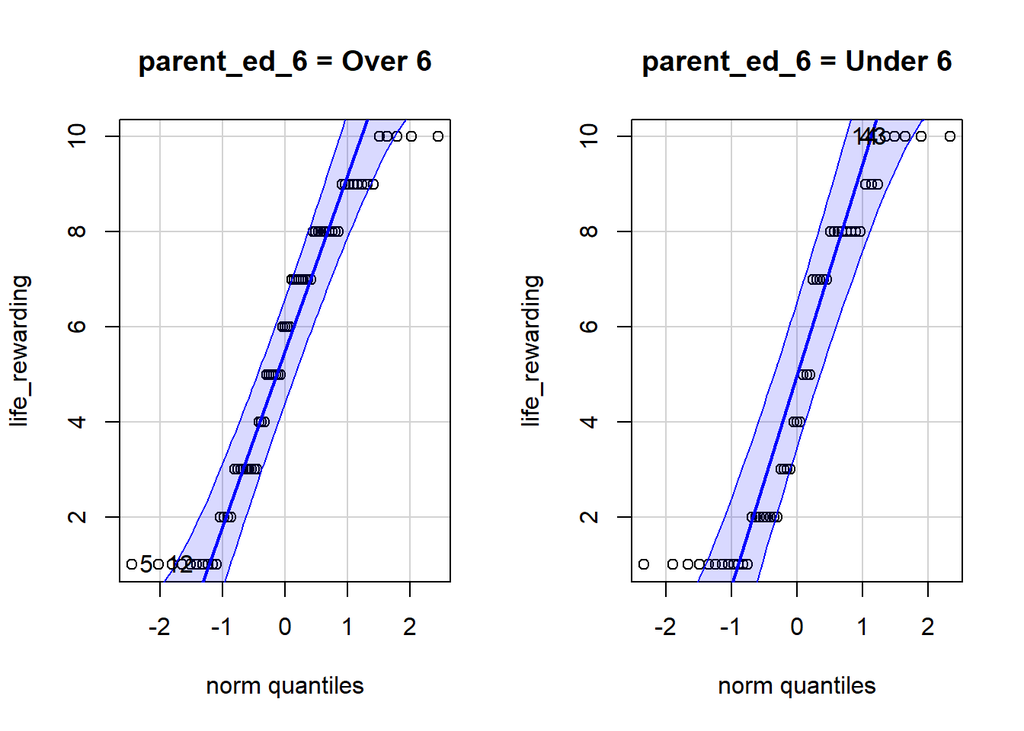

```r
qqPlot(life_rewarding ~ parent_ed_6, data = life_r_ed)
```

We can see that the data is mostly normal, except for the bottom and top for both groups. Note that there is an inherent skew because life_rewarding is a step-wise scale and not continuous, which forces values that could otherwise be in between numbers up or down and creates a staircase effect.

## Kruskal Test Results

```r
test <- kruskal.test(life_rewarding ~ parent_ed_6, data = life_r_ed)
test
```

```
##
##  Kruskal-Wallis rank sum test
##
## data:  life_rewarding by parent_ed_6
## Kruskal-Wallis chi-squared = 1.6419, df = 1, p-value = 0.2001
```

Our p value is .2001 which means that there is not enough evidence to suggest that the distributions are different. Our chi-squared value was 1.6419 with df = 1.

## Conclusion

Although there is a visual difference in the box plot, the Kruskal Wallis test does not show that there is a statistically significant difference. This would suggest, at least from a subjective standpoint, that people’s perceptions of how rewarding their life is are not from different distributions based on their perception of their parent’s education levels.

$$H_a: \mu_{\text{life_rewarding}_{(\text{parent_education} > 6)}} \neq
\mu_{\text{life\_rewarding}_{(\text{parent_education} \leq 6)}}$$

## Food

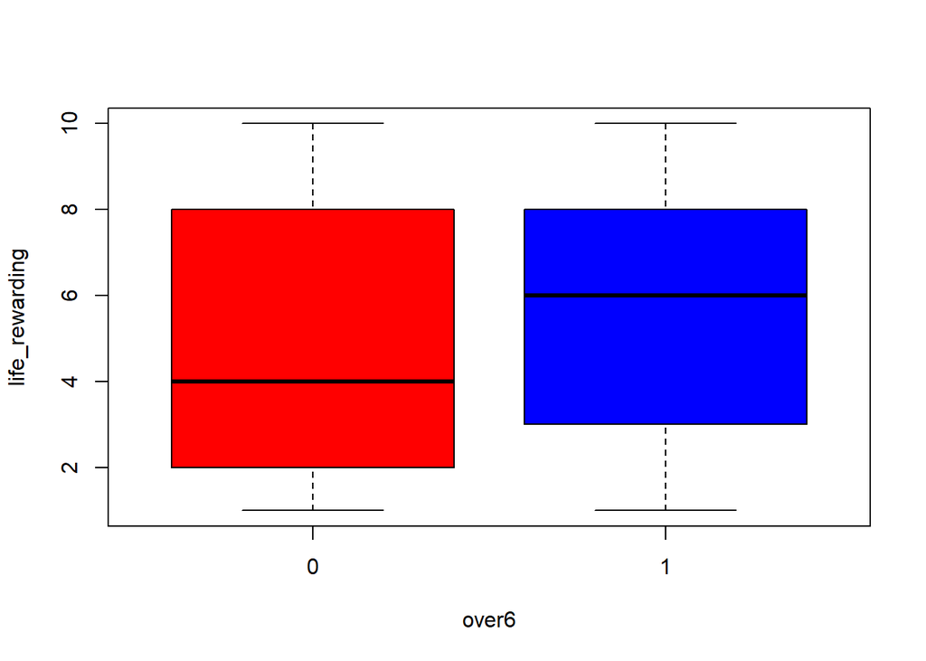

```r
test <- kruskal.test(life_rewarding ~ over6, data = life_r_ed)


boxplot(life_rewarding ~ over6,data = life_r_ed, col=c("red","blue"))
```

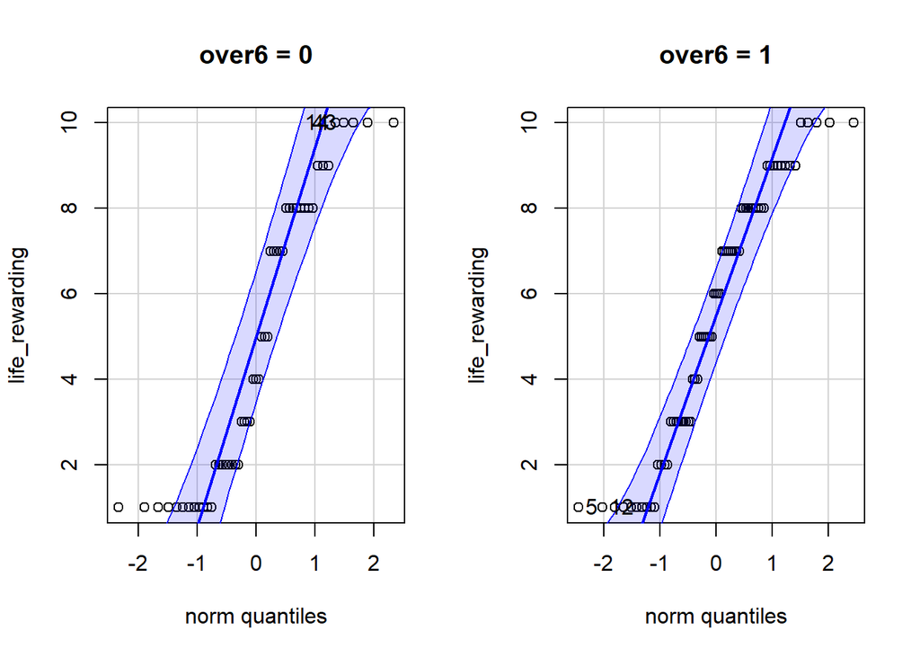

```r
qqPlot(life_rewarding ~ over6, data = life_r_ed)
```

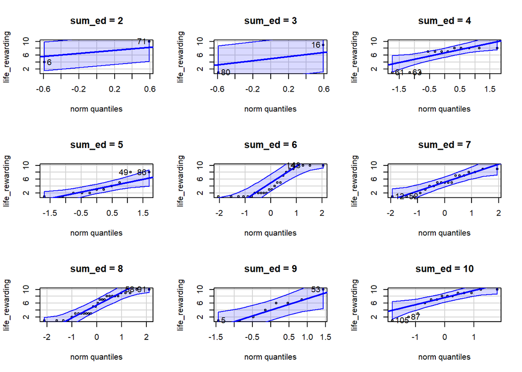

```r
qqPlot(life_rewarding ~ sum_ed, data = life_r_ed)
```

```r
test
```

```
##
##  Kruskal-Wallis rank sum test
##
## data:  life_rewarding by over6
## Kruskal-Wallis chi-squared = 1.6419, df = 1, p-value = 0.2001
```

```r
summary(test)
```

```
##           Length Class  Mode
## statistic 1      -none- numeric
## parameter 1      -none- numeric
## p.value   1      -none- numeric
## method    1      -none- character
## data.name 1      -none- character
```